# Appendix 2 STA206 Final Project

## — Model 6: stepAIC with all polynomial terms (no interactions) —

```r
n<-nrow(SW_DATA_LRG)
w_ii<-1/(SW_DATA_LRG$fAbs_UNC^2) #Weights for WLS
EC_only_mod <- lm(fAbs~EC-1, data=SW_DATA_LRG,weights=w_ii)

f<-update(formula(full_mod), ~ +.+I(EC^2)+I(OC^2)+I(OP^2)+I(AL^2)+I(AS^2)+I(BR^2)+I(CA^2)+I(CL^2)+I(CR^2)+I(CU^2)+I(FE^2)+I(PB^2)+I(MG^2)+I(MN^2)+I(NI^2)+I(NO3^2)+I(N2^2)+I(P^2)+I(K^2)+I(RB^2)+I(SE^2)+I(SI^2)+I(NA.^2)+I(SR^2)+I(SO4^2)+I(S^2)+I(TI^2)+I(V^2)+I(ZN^2)+I(ZR^2))

full_mod2 <- lm(f, data=SW_DATA_LRG,weights=w_ii)

## --- Let's use BIC for smaller model ---
fit_FO6<-stepAIC(EC_only_mod,scope=list(upper=formula(full_mod2), lower = formula(EC_only_mod)), direction="both", k=log(n), trace = FALSE)
summary(fit_FO6)
```

```
##
## Call:
## lm(formula = fAbs ~ EC + SI + CU + FE + TI + K + I(MG^2) + NA. +
##     CA + I(CR^2) + MG + I(K^2) + I(OP^2) + I(EC^2) + CL - 1,
##     data = SW_DATA_LRG, weights = w_ii)
##
## Weighted Residuals:
##      Min       1Q   Median       3Q      Max
## -27.9533  -1.5982  -0.0146   1.3503  12.1812
##
## Coefficients:
##           Estimate Std. Error t value Pr(>|t|)
## EC       9.298e+00  2.382e-01  39.028  < 2e-16 ***
## SI      -2.523e+00  2.635e-01  -9.578  < 2e-16 ***
## CU       3.766e+01  6.418e+00   5.868 5.65e-09 ***
## FE       2.303e+01  1.402e+00  16.434  < 2e-16 ***
## TI      -1.161e+02  8.374e+00 -13.859  < 2e-16 ***
## K        9.553e+00  1.297e+00   7.366 3.19e-13 ***
## I(MG^2)  2.857e+01  8.855e+00   3.227  0.00128 **
## NA.      3.445e+00  3.680e-01   9.361  < 2e-16 ***
## CA       1.800e+00  3.836e-01   4.691 3.01e-06 ***
## I(CR^2) -3.073e+05  7.601e+04  -4.042 5.61e-05 ***
## MG      -1.321e+01  1.566e+00  -8.434  < 2e-16 ***
## I(K^2)  -1.370e+01  2.979e+00  -4.597 4.71e-06 ***
## I(OP^2)  2.102e+00  2.524e-01   8.329  < 2e-16 ***
## I(EC^2) -7.092e-01  1.323e-01  -5.361 9.84e-08 ***
## CL      -2.038e+00  6.188e-01  -3.293  0.00102 **
## ---
## Signif. codes:  0 '***' 0.001 '**' 0.01 '*' 0.05 '.' 0.1 ' ' 1
##
## Residual standard error: 2.654 on 1249 degrees of freedom
## Multiple R-squared:  0.9563, Adjusted R-squared:  0.9558
## F-statistic:  1824 on 15 and 1249 DF,  p-value: < 2.2e-16
```

```r
formula(fit_FO6)
```

```
## fAbs ~ EC + SI + CU + FE + TI + K + I(MG^2) + NA. + CA + I(CR^2) +
##     MG + I(K^2) + I(OP^2) + I(EC^2) + CL - 1
```

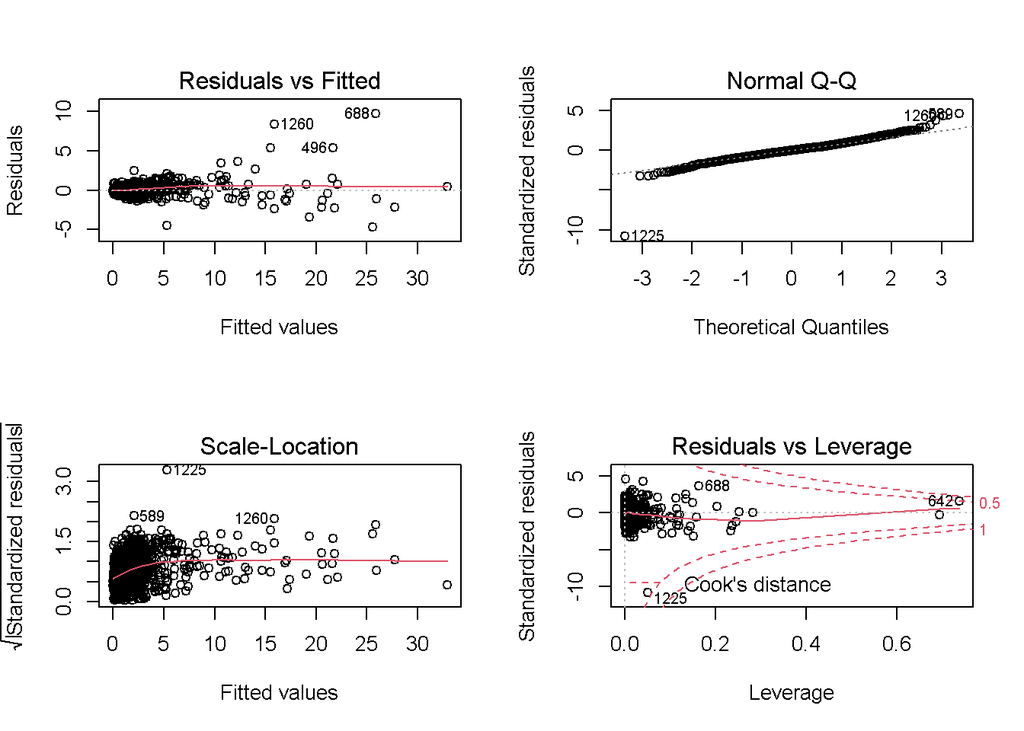

Figure A2.17: Core diagnostics for ‘Polynomial stepAIC’ model

```r
par(mfrow=c(2,2))
plot(fit_FO6)
```

```r
glance(fit_FO6)
```

```
## # A tibble: 1 x 12
##   r.squared adj.r.squared sigma statistic p.value    df logLik   AIC   BIC
##       <dbl>         <dbl> <dbl>     <dbl>   <dbl> <dbl>  <dbl> <dbl> <dbl>
## 1     0.956         0.956  2.65     1824.       0    15  -775. 1582. 1665.
## # ... with 3 more variables: deviance <dbl>, df.residual <int>, nobs <int>
```

```r
anova(fit_FO6)
```

```
## Analysis of Variance Table
##
## Response: fAbs
##             Df Sum Sq Mean Sq   F value    Pr(>F)
## EC           1 178578  178578 25344.589 < 2.2e-16 ***
## SI           1   8690    8690  1233.362 < 2.2e-16 ***
## CU           1   1003    1003   142.342 < 2.2e-16 ***
## FE           1    359     359    50.904 1.639e-12 ***
## TI           1   1067    1067   151.373 < 2.2e-16 ***
## K            1    673     673    95.586 < 2.2e-16 ***
## I(MG^2)      1    255     255    36.178 2.361e-09 ***
## NA.          1    435     435    61.790 8.201e-15 ***
## CA           1    104     104    14.718 0.0001311 ***
## I(CR^2)      1     98      98    13.935 0.0001978 ***
## MG           1    307     307    43.532 6.144e-11 ***
## I(K^2)       1    423     423    60.059 1.897e-14 ***
## I(OP^2)      1    501     501    71.107 < 2.2e-16 ***
## I(EC^2)      1    222     222    31.449 2.519e-08 ***
## CL           1     76      76    10.841 0.0010207 **
## Residuals 1249   8800       7
## ---
## Signif. codes:  0 '***' 0.001 '**' 0.01 '*' 0.05 '.' 0.1 ' ' 1
```

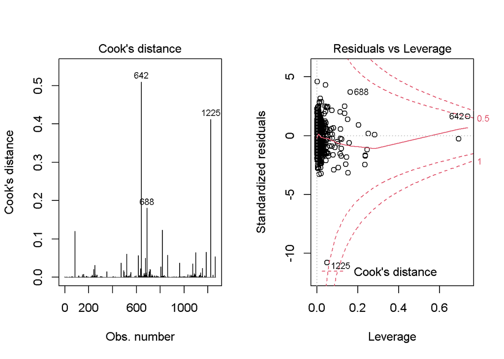

Figure A2.18: COre diagnostics for ‘Polynomial stepAIC’ model (zoomed)

```r
A6<-augment(fit_FO6)
## --- Let's just look at residuals ---
# --- Let's look at cook's distance...
#plot(fit_FO6, which=1)
par(mfrow=c(1,2))
plot(fit_FO6, which=4)
plot(fit_FO6, which=5)
```

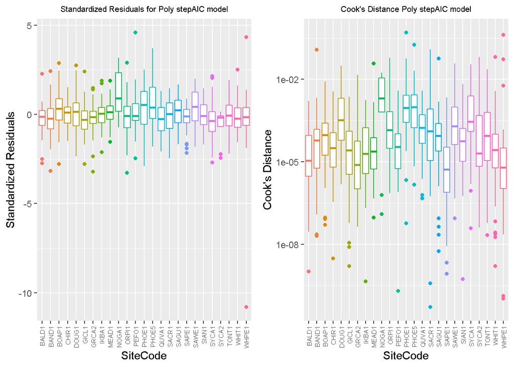

Figure A2.19: side-by-side boxplot for stand. resid, and Cook’s D for ‘Polynomial stepAIC’ model

```r
SW_DATA_LRG_A6<-add_column(SW_DATA_LRG,A6$.std.resid,A6$.cooksd)
Q1<-ggplot(SW_DATA_LRG_A6,aes(x=SiteCode,y=A6$.std.resid,color=SiteCode))+
  geom_boxplot()+
  theme(plot.title=element_text(hjust = 0.5,size=8))+
  theme(legend.position = "none",axis.text.x = element_text(angle = 90, vjust = 0.5, hjust=1,size=6))+ylab("Standardized Residuals")+ggtitle("Standardized Residuals for Poly stepAIC model")
Q2<-ggplot(SW_DATA_LRG_A6,aes(x=SiteCode,y=A6$.cooksd,color=SiteCode))+
  geom_boxplot()+
  theme(plot.title=element_text(hjust = 0.5,size=8))+
  theme(legend.position = "none",axis.text.x = element_text(angle = 90, vjust = 0.5, hjust=1,size=6))+ylab("Cook's Distance")+scale_y_log10()+ggtitle("Cook's Distance Poly stepAIC model")
grid.arrange(Q1,Q2,nrow=1)
```

## — Model 7: stepAIC with only squared carbon terms —

- From the beginning of this analysis, it seemed plausible that EC needed to be squared. Perhaps since OC,EC, and OP are all correlated strongly, these should be squared as well.
- LEt’s try it out in stepAIC: I expect all carbon terms to show up and SiteCode will be included again.

```r
n<-nrow(SW_DATA_LRG)
w_ii<-1/(SW_DATA_LRG$fAbs_UNC^2) #Weights for WLS
EC_only_mod <- lm(fAbs~EC-1, data=SW_DATA_LRG,weights=w_ii)

f2<-update(formula(full_mod), ~ +.+I(EC^2)+I(OC^2)+I(OP^2))

full_mod3 <- lm(f2, data=SW_DATA_LRG,weights=w_ii)

## --- Let's use BIC for smaller model ---
fit_FO7<-stepAIC(EC_only_mod,scope=list(upper=formula(full_mod3), lower = formula(EC_only_mod)), direction="both", k=log(n), trace = FALSE)
summary(fit_FO7)
```

```
##
## Call:
## lm(formula = fAbs ~ EC + SI + CU + FE + TI + K + NA. + MG + CA +
##     I(OP^2) + I(EC^2) + CL - 1, data = SW_DATA_LRG, weights = w_ii)
##
## Weighted Residuals:
##      Min       1Q   Median       3Q      Max
## -29.1993  -1.6015  -0.0288   1.3546  12.3802
##
## Coefficients:
##          Estimate Std. Error t value Pr(>|t|)
## EC         9.8575     0.2022  48.744  < 2e-16 ***
## SI        -1.7810     0.2292  -7.771 1.61e-14 ***
## CU        37.5506     6.4548   5.817 7.58e-09 ***
## FE        19.8893     1.2889  15.431  < 2e-16 ***
## TI      -104.0715     8.2004 -12.691  < 2e-16 ***
## K          4.4555     0.7031   6.337 3.26e-10 ***
## NA.        3.3946     0.3346  10.145  < 2e-16 ***
## MG        -8.3332     0.9982  -8.348  < 2e-16 ***
## CA         1.6808     0.3877   4.336 1.57e-05 ***
## I(OP^2)    2.1064     0.2556   8.241 4.26e-16 ***
## I(EC^2)   -0.9298     0.1245  -7.465 1.55e-13 ***
## CL        -2.4103     0.5986  -4.027 6.00e-05 ***
## ---
## Signif. codes:  0 '***' 0.001 '**' 0.01 '*' 0.05 '.' 0.1 ' ' 1
##
## Residual standard error: 2.69 on 1252 degrees of freedom
## Multiple R-squared:  0.9551, Adjusted R-squared:  0.9546
## F-statistic:  2218 on 12 and 1252 DF,  p-value: < 2.2e-16
```

```r
formula(fit_FO7)
```

```
## fAbs ~ EC + SI + CU + FE + TI + K + NA. + MG + CA + I(OP^2) +
##     I(EC^2) + CL - 1
```

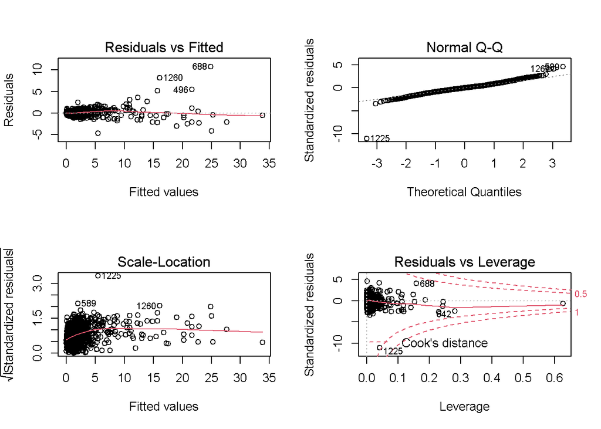

Figure A2.20: core diagnostics for ‘Carbon Polynomial stepAIC’ model

```r
par(mfrow=c(2,2))
plot(fit_FO7)
```

```r
glance(fit_FO7)
```

```
## # A tibble: 1 x 12
##   r.squared adj.r.squared sigma statistic p.value    df logLik   AIC   BIC
##       <dbl>         <dbl> <dbl>     <dbl>   <dbl> <dbl>  <dbl> <dbl> <dbl>
## 1     0.955         0.955  2.69     2218.       0    12  -793. 1613. 1680.
## # ... with 3 more variables: deviance <dbl>, df.residual <int>, nobs <int>
```

```r
anova(fit_FO7)
```

```
## Analysis of Variance Table
##
## Response: fAbs
##             Df Sum Sq Mean Sq   F value    Pr(>F)
## EC           1 178578  178578 24681.354 < 2.2e-16 ***
## SI           1   8690    8690  1201.087 < 2.2e-16 ***
## CU           1   1003    1003   138.618 < 2.2e-16 ***
## FE           1    359     359    49.572 3.145e-12 ***
## TI           1   1067    1067   147.411 < 2.2e-16 ***
## K            1    673     673    93.085 < 2.2e-16 ***
## NA.          1    298     298    41.192 1.953e-10 ***
## MG           1    612     612    84.573 < 2.2e-16 ***
## CA           1    131     131    18.145 2.200e-05 ***
## I(OP^2)      1    498     498    68.775 2.820e-16 ***
## I(EC^2)      1    507     507    70.035 < 2.2e-16 ***
## CL           1    117     117    16.213 6.001e-05 ***
## Residuals 1252   9059       7
## ---
## Signif. codes:  0 '***' 0.001 '**' 0.01 '*' 0.05 '.' 0.1 ' ' 1
```

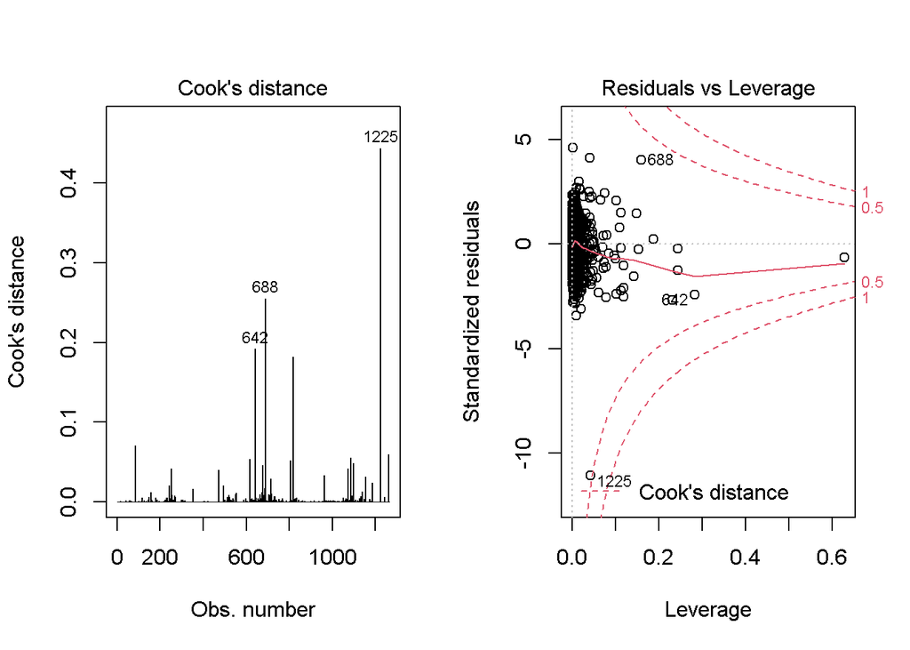

Figure A2.21: Core diagnostics for ‘Carbon Polynomial stepAIC’ model (zoomed)

```r
A7<-augment(fit_FO7)
## --- Let's just look at residuals ---
# --- Let's look at cook's distance...
#plot(fit_FO7, which=1)
par(mfrow=c(1,2))
plot(fit_FO7, which=4)
plot(fit_FO7, which=5)
```

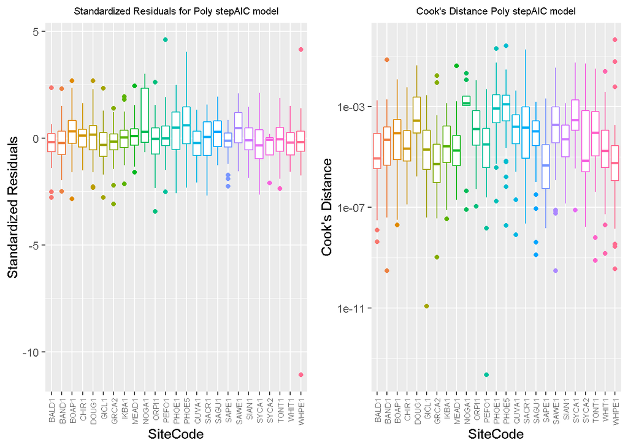

Figure A2.22: side-by-side boxplot for stand. resid, and Cook’s D for ‘Carbon Polynomial stepAIC’ model

```r
SW_DATA_LRG_A7<-add_column(SW_DATA_LRG,A7$.std.resid,A7$.cooksd)
Q1<-ggplot(SW_DATA_LRG_A7,aes(x=SiteCode,y=A7$.std.resid,color=SiteCode))+
  geom_boxplot()+
  theme(plot.title=element_text(hjust = 0.5,size=8))+
  theme(legend.position = "none",axis.text.x = element_text(angle = 90, vjust = 0.5, hjust=1,size=6))+ylab("Standardized Residuals")+ggtitle("Standardized Residuals for Poly stepAIC model")

Q2<-ggplot(SW_DATA_LRG_A7,aes(x=SiteCode,y=A7$.cooksd,color=SiteCode))+
  geom_boxplot()+
  theme(plot.title=element_text(hjust = 0.5,size=8))+
  theme(legend.position = "none",axis.text.x = element_text(angle = 90, vjust = 0.5, hjust=1,size=6))+ylab("Cook's Distance")+scale_y_log10()+ggtitle("Cook's Distance Poly stepAIC model")
grid.arrange(Q1,Q2,nrow=1)
```

### — Comments on Model 7 —

1. While not as beautiful as the last model (in terms of residuals), this model is still very reasonable and more defensible IMO.
2. Overall, we see (again) that variables all highly correlated to soil are selected (Ca,Si,Fe,Mg,Ti,K), some NaCl indicating likely marine impacts,
3. Contrary to my expectations, SiteCode was not needed which does make each site mode influential on a site-by-site basis.
4. Regardless, I like this model. I think it’s time to look at how well our top models predict samples in the test set.

## — Step 8: Model predictions, test set performances —

```r
## --- Model predictions ---
Yhat_3<-predict(fit_FO3, SW_DATA_test)
Yhat_4<-predict(fit_FO4, SW_DATA_LRG_test)
Yhat_6<-predict(fit_FO6, SW_DATA_LRG_test)
Yhat_7<-predict(fit_FO7, SW_DATA_LRG_test)
## --- Test set errors per model --
# --- Didn't screen all NAs from test set ---
e_3<-SW_DATA_test$fAbs-Yhat_3
e_4<-SW_DATA_LRG_test$fAbs-Yhat_4
e_6<-SW_DATA_LRG_test$fAbs-Yhat_6
e_7<-SW_DATA_LRG_test$fAbs-Yhat_7
e_3<-e_3[complete.cases(e_3)]
e_4<-e_4[complete.cases(e_4)]
e_6<-e_6[complete.cases(e_6)]
e_7<-e_7[complete.cases(e_7)]
## --- Performance metrics ---
SSE_3<-sum(e_3^2)
SSE_4<-t(e_4)%*%e_4
SSE_6<-t(e_6)%*%e_6
SSE_7<-t(e_7)%*%e_7
Y_3<-SW_DATA_test$fAbs
Y_467<-SW_DATA_LRG_test$fAbs
SST_3<-sum((Y_3-mean(Y_3))^2)
SST_4<-sum((Y_467-mean(Y_467))^2)
SST_6<-sum((Y_467-mean(Y_467))^2)
SST_7<-sum((Y_467-mean(Y_467))^2)
## --- Rsquared ---
Rsqrd_3<-1-SSE_3/SST_3
Rsqrd_4<-1-SSE_4/SST_4
Rsqrd_6<-1-SSE_6/SST_6
Rsqrd_7<-1-SSE_7/SST_7
## --- RMSEP ---
RMSEP_3<-sqrt(SSE_3/length(e_3))
RMSEP_4<-sqrt(SSE_4/length(e_4))
RMSEP_6<-sqrt(SSE_6/length(e_6))
RMSEP_7<-sqrt(SSE_7/length(e_7))
## --- mean absolute percentage error (MAPE) ---
## --- Need to exclude all zero fAbs values ---
abs_rel_diff3<-abs(e_3/Y_3)
abs_rel_diff4<-abs(e_4/Y_467)
abs_rel_diff6<-abs(e_6/Y_467)
abs_rel_diff7<-abs(e_7/Y_467)

# --- Histogram of rel_diff: log transform ---
#par(mfrow=c(2,2))
#hist(log(abs_rel_diff3))
#hist(log(abs_rel_diff4))
#hist(log(abs_rel_diff6))
#hist(log(abs_rel_diff7))

# --- Log transform, find mean, transform back
MAPE_3<-100*exp(mean(log(abs_rel_diff3[!is.infinite(abs_rel_diff3)]),na.rm=TRUE))
MAPE_4<-100*exp(mean(log(abs_rel_diff4[!is.infinite(abs_rel_diff4)]),na.rm=TRUE))
MAPE_6<-100*exp(mean(log(abs_rel_diff6[!is.infinite(abs_rel_diff6)]),na.rm=TRUE))
MAPE_7<-100*exp(mean(log(abs_rel_diff7[!is.infinite(abs_rel_diff7)]),na.rm=TRUE))
## --- Maybe compare to relative uncertainty? ---
rel_unc<-SW_DATA_all$fAbs_UNC[SW_DATA_all$fAbs > 0]/SW_DATA_all$fAbs[SW_DATA_all$fAbs > 0]
abs_rel_unc<-abs(rel_unc[!is.infinite(rel_unc)])
MARU<-exp(mean(log(abs_rel_unc)))
```

```r
abs_rel_diff3trn<-abs((SW_DATA$fAbs-fit_FO3$fitted.values)/SW_DATA$fAbs)
abs_rel_diff4trn<-abs((SW_DATA_LRG$fAbs-fit_FO4$fitted.values)/SW_DATA_LRG$fAbs)
abs_rel_diff6trn<-abs((SW_DATA_LRG$fAbs-fit_FO6$fitted.values)/SW_DATA_LRG$fAbs)
abs_rel_diff7trn<-abs((SW_DATA_LRG$fAbs-fit_FO7$fitted.values)/SW_DATA_LRG$fAbs)
# --- Mean absolute percentage error (training set) ---
MAPE_3trn<-100*exp(mean(log(abs_rel_diff3trn[!is.infinite(abs_rel_diff3trn)]),na.rm=TRUE))
MAPE_4trn<-100*exp(mean(log(abs_rel_diff4trn[!is.infinite(abs_rel_diff4trn)]),na.rm=TRUE))
MAPE_6trn<-100*exp(mean(log(abs_rel_diff6trn[!is.infinite(abs_rel_diff6trn)]),na.rm=TRUE))
MAPE_7trn<-100*exp(mean(log(abs_rel_diff7trn[!is.infinite(abs_rel_diff7trn)]),na.rm=TRUE))
## --- Maybe compare to relative uncertainty? ---
```

```r
## --- BS function ---
MARU_boot_fun<-function(abs_rel_diff,indices){
  MARU_out<-exp(mean(log(abs_rel_diff[indices])))
  return(MARU_out)
}

## --
MARU_BS<-boot(abs_rel_unc, statistic=MARU_boot_fun, R=2000)
MARU_CI<-boot.ci(MARU_BS,conf=0.95,type="perc")
MARU_CI
```

```
## BOOTSTRAP CONFIDENCE INTERVAL CALCULATIONS
## Based on 2000 bootstrap replicates
##
## CALL :
## boot.ci(boot.out = MARU_BS, conf = 0.95, type = "perc")
##
## Intervals :
## Level     Percentile
## 95%   ( 0.1331,  0.1429 )
## Calculations and Intervals on Original Scale
```

```r
TOP_MOD_fit<-tibble(Y_3=Y_3,Yhat_3=Yhat_3,Y_4=Y_467,Yhat_4=Yhat_4,Y_6=Y_467,Yhat_6=Yhat_6,Y_7=Y_467,Yhat_7=Yhat_7,SiteCode=SW_DATA_test$SiteCode)
```

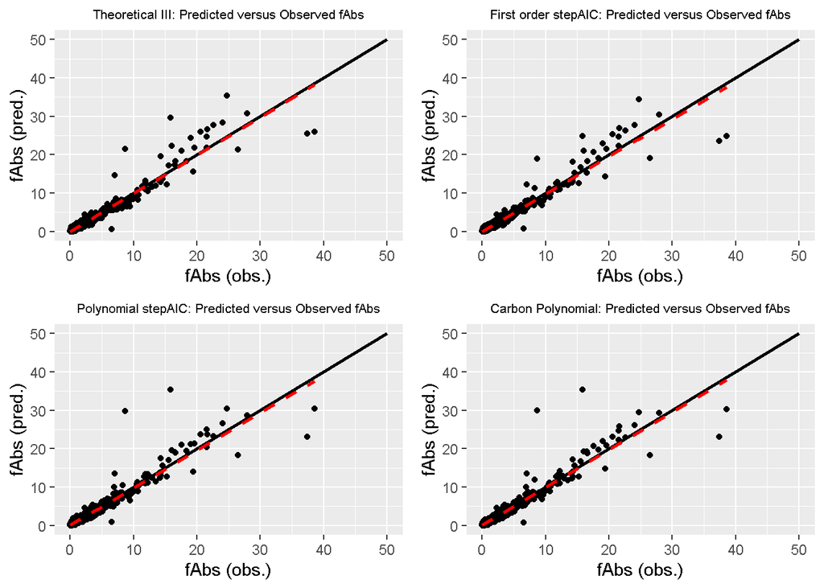

Figure A2.23: Cross plots for selected models in Table 1

```r
M3<-qplot(Y_3,Yhat_3, data = TOP_MOD_fit, main="Theoretical III: Predicted versus Observed fAbs",xlim=c(0,50),ylim=c(0,50))+
  theme(plot.title = element_text(hjust = 0.5,size =8))+ylab("fAbs (pred.)")+xlab("fAbs (obs.)")+ geom_segment(x=0,y=0,xend=50,yend=50,size=1)+ geom_smooth(method="lm",se=FALSE,linetype=2,color="red")
M4<-qplot(Y_4,Yhat_4, data = TOP_MOD_fit, main="First order stepAIC: Predicted versus Observed fAbs",xlim=c(0,50),ylim=c(0,50))+
  theme(plot.title = element_text(hjust = 0.5,size =8))+ylab("fAbs (pred.)")+xlab("fAbs (obs.)")+ geom_segment(x=0,y=0,xend=50,yend=50,size=1)+ geom_smooth(method="lm",se=FALSE,linetype=2,color="red")
M6<-qplot(Y_6,Yhat_6, data = TOP_MOD_fit, main="Polynomial stepAIC: Predicted versus Observed fAbs",xlim=c(0,50),ylim=c(0,50))+
  theme(plot.title = element_text(hjust = 0.5,size =8))+ylab("fAbs (pred.)")+xlab("fAbs (obs.)")+ geom_segment(x=0,y=0,xend=50,yend=50,size=1)+ geom_smooth(method="lm",se=FALSE,linetype=2,color="red")
M7<-qplot(Y_7,Yhat_7, data = TOP_MOD_fit, main="Carbon Polynomial: Predicted versus Observed fAbs",xlim=c(0,50),ylim=c(0,50))+
  theme(plot.title = element_text(hjust = 0.5,size =8))+ylab("fAbs (pred.)")+xlab("fAbs (obs.)")+ geom_segment(x=0,y=0,xend=50,yend=50,size=1)+ geom_smooth(method="lm",se=FALSE,linetype=2,color="red")

grid.arrange(M3,M4,M6,M7,nrow=2)
```

### — Residuals plot comparison for report —

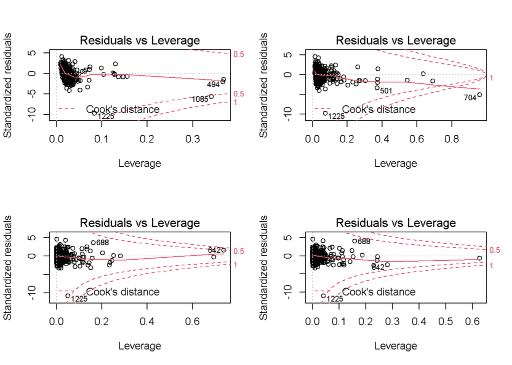

Figure (4) & A2.24: Standardize Residual comparison for the top models in Table 1

```r
par(mfrow=c(2,2))
plot(fit_FO3, which=5)
plot(fit_FO4, which=5)
plot(fit_FO6, which=5)
plot(fit_FO7, which=5)
```

#### — Bootstrapping CIs for reg. coefficients —

```r
# function to obtain regression weights
bs <- function(formula, data_in, indices) {
  d <- data_in[indices,] # allows boot to select sample
  w_ii<-1/d$fAbs_UNC^2
  fit <- lm(formula, data=d,weights = w_ii)
  return(coef(fit))
}
# ---- bootstrapping with 1000 replications ----
BS_FO3 <- boot(data=SW_DATA, statistic=bs,
   R=1000, formula=formula(fit_FO3))
boot.ci(BS_FO3,conf=0.95,type="perc",index=1) #EC
```

```
## BOOTSTRAP CONFIDENCE INTERVAL CALCULATIONS
## Based on 1000 bootstrap replicates
##
## CALL :
## boot.ci(boot.out = BS_FO3, conf = 0.95, type = "perc", index = 1)
##
## Intervals :
## Level     Percentile
## 95%   ( 7.695, 10.395 )
## Calculations and Intervals on Original Scale
```

```r
BS_FO4 <- boot(data=SW_DATA_LRG, statistic=bs,
   R=1000, formula=formula(fit_FO4))
boot.ci(BS_FO4,conf=0.95,type="perc",index=1) #EC
```

```
## BOOTSTRAP CONFIDENCE INTERVAL CALCULATIONS
## Based on 1000 bootstrap replicates
##
## CALL :
## boot.ci(boot.out = BS_FO4, conf = 0.95, type = "perc", index = 1)
##
## Intervals :
## Level     Percentile
## 95%   ( 7.049,  9.733 )
## Calculations and Intervals on Original Scale
```

```r
BS_FO6 <- boot(data=SW_DATA_LRG, statistic=bs,
   R=1000, formula=formula(fit_FO6))
boot.ci(BS_FO6,conf=0.95,type="perc",index=1) #EC
```

```
## BOOTSTRAP CONFIDENCE INTERVAL CALCULATIONS
## Based on 1000 bootstrap replicates
##
## CALL :
## boot.ci(boot.out = BS_FO6, conf = 0.95, type = "perc", index = 1)
##
## Intervals :
## Level     Percentile
## 95%   ( 8.889, 12.850 )
## Calculations and Intervals on Original Scale
```

```r
BS_FO7 <- boot(data=SW_DATA_LRG, statistic=bs,
   R=1000, formula=formula(fit_FO7))
boot.ci(BS_FO7,conf=0.95,type="perc",index=1) #EC
```

```
## BOOTSTRAP CONFIDENCE INTERVAL CALCULATIONS
## Based on 1000 bootstrap replicates
##
## CALL :
## boot.ci(boot.out = BS_FO7, conf = 0.95, type = "perc", index = 1)
##
## Intervals :
## Level     Percentile
## 95%   ( 9.437, 12.211 )
## Calculations and Intervals on Original Scale
```

#### — Failed PCA idea —

Not informative

```r
## --- Not informative!! ---
stepAIC_vars1<-attr(fit_FO4$terms,"term.labels")
stepAIC_vars<-stepAIC_vars1[stepAIC_vars1 != "SiteCode"]
SW_DATA_PCA<-SW_DATA_LRG %>% dplyr::select(all_of(stepAIC_vars))
## --- I'm not going to standardize as that not what was done in the regression model ---

## --- Let's normalize the data by PM ---
SW_DATA_PCA2<-SW_DATA_all[-ind_test,] %>% dplyr::select(all_of(stepAIC_vars) | matches("PM2.5") & !contains("UNC"))

SW_DATA_PCA_norm1<-SW_DATA_PCA2 %>% transmute(all_of(SW_DATA_PCA2)/PM2.5)
SW_DATA_PCA_norm<-SW_DATA_PCA_norm1 %>% dplyr::select(!matches("PM2.5"))

SW_DATA_PCA_norm<-SW_DATA_PCA_norm[complete.cases(SW_DATA_PCA_norm),]

# --- Check that all are less than 1, which must be true otherwise mass balance is violated ---
##---------------------------------------

PCA_stepAIC<-prcomp(log(data.matrix(SW_DATA_PCA_norm)+1), center=TRUE,scale=FALSE)
## --- Check out the scree plot ---
screeplot(PCA_stepAIC,type="lines")

ggbiplot(PCA_stepAIC, choices = 1:2, groups =SW_DATA_LRG$SiteCode)
biplot(PCA_stepAIC, choices = 1:2,xlabs = rep(".",nrow(SW_DATA_PCA)))
ggbiplot(PCA_stepAIC, choices = 2:3, groups =SW_DATA_LRG$SiteCode)
biplot(PCA_stepAIC, choices = 2:3,xlabs = rep(".",nrow(SW_DATA_PCA)))
ggbiplot(PCA_stepAIC, choices = 3:4, groups =SW_DATA_LRG$SiteCode)
biplot(PCA_stepAIC, choices = 3:4,xlabs = rep(".",nrow(SW_DATA_PCA)))
```

```r
R2_EC<-sum(anova(fit_FO)$'Sum Sq'[1])/sum(anova(fit_FO)$'Sum Sq')
R2_EC2<-sum(anova(fit_FO2)$'Sum Sq'[1])/sum(anova(fit_FO2)$'Sum Sq')
R2_EC3<-sum(anova(fit_FO3)$'Sum Sq'[1])/sum(anova(fit_FO3)$'Sum Sq')
R2_EC4<-sum(anova(fit_FO4)$'Sum Sq'[1])/sum(anova(fit_FO4)$'Sum Sq')
R2_EC6<-sum(anova(fit_FO6)$'Sum Sq'[1])/sum(anova(fit_FO6)$'Sum Sq')
R2_EC7<-sum(anova(fit_FO7)$'Sum Sq'[1])/sum(anova(fit_FO7)$'Sum Sq')
#Ah yes, of course!
```